# Variational Fourier Regression

Matthew Fisher

# Introduction

## Big Picture Idea

For a given loss $\ell$, the regression task is

$$\inf_{f \in \mathcal{F}} \, \mathbb{E}[\ell(f(X), Y)],$$

seeking functions $f$ with good *predictive performance*.

Performance depends on

1. **Choice of loss** (e.g. squared error, cross-entropy),
2. **Choice of hypothesis class $\mathcal{F}$** (linear models, kernels, neural networks),
3. **Choice of regularisation** (norm constraints, weight decay, spectral penalties).

Successful methods exploit **inductive biases** matched to data geometry. E.g. CNNs for images, GNNs for graphs, transformers for sequences, etc.

## Fourier Regression

### Fourier viewpoint

Any $f \in L^2(\mathbb{R}^d)$ has the Fourier representation

$$f(x) = \int_{\mathbb{R}^d} \hat f(\theta) \, e^{-i \theta^\top x} \, d\theta,$$

where $\hat f$ encodes the **spectral content** of $f$. In practice, we cannot learn $\hat f$ directly, but we can **approximate $f$ by truncating or discretising the integral**:

$$f(x) \approx \sum_{j=1}^m \alpha_j e^{-i \theta_j^\top x},$$

with frequencies ${\theta_j}$ drawn either adaptively or at random. This turns regression into **learning coefficients in a Fourier basis**.

## Fourier Regression

### Why Fourier?

Fourier analysis is the harmonic analysis associated with the geometry of Euclidean space:

1. $\mathbb{R}^d$ is a **locally compact abelian (LCA) group** under addition.
2. Its Haar measure is the **Lebesgue measure**, the unique shift-invariant measure.
3. By **Pontryagin duality**, the characters of this group are the exponentials $e^{-i \theta^\top x}$, and the Fourier transform is the corresponding Gelfand transform.

Thus, the Fourier basis encodes **translation symmetry** - the fundamental symmetry of Euclidean space.

## Fourier Regression

### Generalisations and Connections

There are analogous *Fourier transforms* on different **LCA** groups:

- On $\mathbb{Z}/n\mathbb{Z}$ the dual group gives the **Discrete Fourier Transform**.
- On the torus $\mathbb{R}/\mathbb{Z}$, it yields the **Fourier series**.
- On the $p$-adic numbers $\mathbb{Q}_p$, there is a corresponding Fourier transform (discussed later).
- More generally, **shift-invariant kernels** admit a Fourier spectral representation (Bochner’s theorem). This underlies *random Fourier features* and spectral kernel methods.

So “Fourier regression” is not just heuristic: it’s a **principled basis expansion** matched to the group structure of the data, with natural regularisation in the frequency domain (e.g. penalising high frequencies).

It **encodes** the inductive bias of shift-invariance.

## Variational Fourier Regression

- How do we learn $\hat{f}(\theta)$?
- Have been working on **variational objectives:**
  $$\mathcal{F}(Q) = \underbrace{\mathcal{L}(Q)}_{\text{Loss}} + \underbrace{\mathrm{KL}(Q \| Q_0)}_{\text{Regulariser}},$$

  where
  1. ▶ $Q$ is a **probability distribution**
  2. ▶ $Q_0$ is a **prior**
- This general objective includes: *Bayesian inference*, *prediction centric inference*, and more! Different methods:
- **Particle Based Methods**
  - ▶ Mean-Field Langevin Dynamics
  - ▶ **Generalisations of SVGD**
  - ▶ Fisher-Rao geometries e.g. mirror descent
- **Parametric Methods**
  - ▶ Normalising flows
  - ▶ Mixtures of Gaussians (e.g. [this paper](https://proceedings.neurips.cc/paper_files/paper/2022/file/5d087955ee13fe9a7402eedec879b9c3-Paper-Conference.pdf))

## Issues

We might want to treat $\hat f$ (the Fourier transform of $f$) as a **probability measure** so that we can plug it directly into the variational framework.

However:

1. **$\hat f$ is not generally a probability measure.**
   - It can be complex-valued, can have negative parts, and is not normalised.
   - Only in special cases (e.g. positive-definite functions, characteristic functions of distributions) can $\hat f$ be directly interpreted as a probability law.
2. **If we *force* it into a probability-measure framework**, then we are really heading in the direction of **Bochner’s theorem**: representing kernels as expectations over Fourier features.
   - In this case, $\hat f$ is no longer “the Fourier transform of the predictor” but is instead treated as a *spectral measure* that defines a kernel.
   - Optimising over such spectral measures corresponds to **kernel learning**, not direct function learning.

### Comparing with Random Fourier Features

By **Bochner’s theorem**: If $k(x-y)$ is a continuous, normalised ($k(0) = 1$), stationary, positive-definite kernel on $\mathbb{R}^d$, then there exists a probability measure $\lambda$ on $\mathbb{R}^d$ such that

$$k(x,y) = \int_{\mathbb{R}^d} e^{i \theta^\top(x-y)} \, d\lambda(\theta).$$

- $\lambda$ is called the **spectral measure**.
- If $k$ is real-valued, $\lambda$ must be symmetric $\lambda(A)=\lambda(-A)$.

**Random Fourier Features (RFF)** approximate this integral via Monte Carlo:

$$k(x,y) \approx \frac{1}{m}\sum_{j=1}^m \cos(\theta_j^\top(x-y)), \quad \theta_j \sim \lambda.$$

If you plug this approximation into **Kernel Ridge Regression**, the predictor has the form

$$f(x) = w^\top \phi(x),$$

where

$$\phi(x) = \big(\cos(\theta_1^\top x), \ldots, \cos(\theta_m^\top x)\big).$$

- The weights $w \in \mathbb{R}^m$ are learned by minimising the regression loss (ridge regression in this finite-dimensional feature space).
- The frequencies ${\theta_j}$ are usually fixed after the initial sampling from $\lambda$, though some variants learn/adapt them.

### Desiderata

To create a **novel approach** (I think), we want to:

- Treat $\hat{f}$ as a function or **signed measure**
- Optimise $\hat{f}$ in an **analogous framework**

# Aside (Gradient flows + SVGD)

## Gradient flows on Riemannian Manifolds

### Gradient flows in Euclidean Space

For a functional $F:\mathbb R^n \to \mathbb R$, the **gradient flow** is
$$\dot x_t = -\nabla F(x_t).$$
This is “steepest descent” with respect to the Euclidean inner product $\langle u,v\rangle=\sum u_i v_i$.

## Gradient flows on Riemannian Manifolds

### Generalising to a Riemannian manifold

Let $(\mathcal M,g)$ be a Riemannian manifold:

- At each point $p\in\mathcal M$, the tangent space $T_p\mathcal M$ is a vector space of admissible directions.
- The metric tensor $g_p: T_p\mathcal M\times T_p\mathcal M\to \mathbb R$ is an inner product that can vary with $p$.

**Gradient of $F$:** the vector $\nabla^g F(p)\in T_p\mathcal M$ such that
$$dF(p)[\xi] = g_p(\nabla^g F(p), \xi) \quad\forall \xi\in T_p\mathcal M,$$
where $dF$ is the differential (directional derivative).

**Gradient flow:** the ODE
$$\partial_t p_t = -\nabla^g F(p_t), \quad p_t\in\mathcal M.$$

## Gradient flows on Riemannian Manifolds

### Role of tangent space choice

- The definition of $T_p\mathcal M$ tells you **what counts as a direction**.
- Example: in Wasserstein geometry, tangent vectors at a measure $Q$ are velocity fields; in an embedding geometry, tangents are embedding perturbations.

Different tangent models give different possible evolutions.

## Gradient flows on Riemannian Manifolds

### Role of the metric tensor

- The metric tensor tells you how to measure the **size and angle** of tangent vectors.
- “Steepest descent” is always defined relative to this inner product.
- Changing the metric changes the gradient direction.

Example:

- With Euclidean metric, gradient is just $\nabla F$.
- With a preconditioned metric $g(u,v)=u^\top M v$, the gradient becomes $M^{-1}\nabla F$.

## Gradient flows on Riemannian Manifolds

### Exponential map and evolution

Once you have a tangent vector $v\in T_p\mathcal M$, you evolve by following the geodesic starting at $p$ with velocity $v$. This is the **exponential map**:
$$p' = \exp_p(v).$$

So the **evolution rule depends jointly on**:

1. How you define tangents (what’s allowed),
2. How you measure them (the metric tensor), and
3. How you “integrate them back” to the manifold (the exponential map).

## What is SVGD?

Suppose we want to optimise the objective:

$$\mathcal{F}(Q) = \underbrace{\mathcal{L}(Q)}_{\text{Loss}} + \underbrace{\mathrm{KL}(Q \| Q_0)}_{\text{Regulariser}}.$$

A natural idea would be to consider a **Riemannian manifold of probability measures** and perform a gradient flow.

To recover SVGD we use the **Riemannian manifold** of $W_2$ with the tangent space given by Stein RKHS directions.

## What is SVGD?

### Wasserstein $W_2$ Space (Otto construction)

Consider the **Wasserstein-2 space**:
$$W_2(\mathbb{R}^d) = \left\{ P \ \text{probability measure on } \mathbb{R}^d \mid \int |x|^2 dP(x) < \infty \right\}.$$

- **Tangent space** at $P$:
  $$\mathcal{T}_P W_2 = \{ -\nabla \cdot (P v) \mid v \in L^2(P;\mathbb{R}^d) \}.$$
- **Exponential map**: pushing forward $P$ by a transport map
  $$\exp_P(v) = (I + \varepsilon v)_\# P.$$
- **Riemannian metric**:
  $$g_P(v,w) = \int v(x)\cdot w(x) \, dP(x).$$

This equips $W_2$ with a formal Riemannian structure (the Otto calculus).

## What is SVGD?

### Gradient Flow in $W_2$

Given a functional $\mathcal{F}: W_2 \to \mathbb{R}$, the **Wasserstein gradient flow** satisfies:
$$\partial_t P_t = - \nabla \cdot \left(P_t \, \nabla \frac{\delta \mathcal{F}}{\delta P}(x)\right),$$
where $\frac{\delta \mathcal{F}}{\delta P}$ is the first variation of $\mathcal{F}$.

This is a PDE describing the evolution of measures under steepest descent in Wasserstein space.

### Why not just use this?

In practice, directly solving this PDE is intractable. Instead, SVGD takes a **particle approximation**:
$$Q \approx \frac{1}{n} \sum_{i=1}^n \delta_{x_i}.$$

We then evolve the particles $x_i$ along a velocity field $v$ chosen to maximally decrease $\mathcal{F}$.

## What is SVGD?

### Kernelised Stein Gradient

SVGD chooses $v$ from a **Reproducing Kernel Hilbert Space (RKHS)** $\mathcal{H}^d$ of vector fields with kernel $k$.

- Stein’s identity ensures that the optimal direction of steepest descent can be expressed in closed form in this RKHS.
- The resulting particle dynamics are:
  $$x_i \leftarrow x_i + \varepsilon \, \phi^*(x_i),$$
  with update function
  $$\phi^*(\cdot) = \mathbb{E}_{x \sim Q}\big[ \nabla_x \log \pi(x) \, k(x,\cdot) + \nabla_x k(x,\cdot) \big],$$
  where $\pi$ is the target distribution (often $\pi \propto e^{-\mathcal{L}}$).

# Possible Approaches

Recall the **objective:**

Learn the inverse Fourier transform $\hat{f}(\theta)$ as a **signed measure** to create regressor functions

$$f(x) = \int \hat{f}(\theta) e^{-i \theta^\top x} \,\mathrm{d}\theta.$$

## Option 1: Reparameterise

Rewrite our regressors as:

$$\begin{align*}
f(x) &= \int \hat{f}(\theta) e^{-i \theta^\top x} \,\mathrm{d}\theta \\
&= \mathbb{E}_{\theta \sim Q} \left[ a(\theta) e^{-i \theta^\top x} \right].
\end{align*}$$

Effectively decomposes the inverse Fourier transform as:

$$\hat{f}(\theta) = \mathrm{d}Q(\theta) \, a(\theta).$$

**Issues:**

1. A vanilla approach (boring)
2. Need to learn $a$ as well.
3. Effectively just learning a **mixture distribution** $Q$ (similar to current/previous work).
4. The regressor just becomes a product of $a(\theta)$ and a two-layer neural network with cosine activation (but with an interpretation as a spectral mixture).

## Option 2: Two Particle “Swarms”

Treat $\hat{f}$ as a **signed measure** and use the Hahn-Jordan decomposition to write:
$$\hat{f} = a\, Q^+ - b \, Q^-,$$
where $Q^+$ and $Q^-$ are probability measures and $a,b \geq 0$ are non-negative constants. To implement this:

1. Treat both $Q^+$ and $Q^-$ as empirical measures
   $$Q^+ = \sum_{i=1}^m w^+_i \delta_{\theta^+_i}, \quad Q^{-} = \sum_{j = 1}^M w^-_j \delta_{\theta^-_j},$$
2. First take a step to evolve $Q^+$ then a step to evolve $Q^-$ and then a vanilla Euclidean GD on $(a,b)$ (with operator splitting).

**Issues:**

1. Nice idea but seems annoying to implement (and figure out the details)
2. Doubles number of hyperparameters

## Option 3: RKHS Descent

Entirely **abandon** forcing a probability measure and $W_2$. Instead, we optimise directly over a **reproducing kernel Hilbert space (RKHS)**!

- Note: We could’ve just used $L^2$ instead, but an analogue of SVGD does not follow…
- Let $k$ be a PSD kernel with RKHS $\mathcal{H}(k)$. Any **signed measure** $\nu$ can be embedded in the RKHS via
  $$\mu_\nu(\cdot) = \int k(\theta, \cdot) \,\mathrm{d}\nu(\theta)$$

  which induces a **norm**
  $$\| \nu \|_{\mathcal{H}(k)} = \iint k(\theta, \theta') \,\mathrm{d}\nu(\theta) \,\mathrm{d}\nu(\theta').$$
- $\mathcal{H}(k)$ is a Riemannian manifold with tangent space $\mathcal{H}(k)$.
- **Let’s figure out the details!**

# A Natural Generalisation

## Rewriting the Variational Objective

Instead of considering the following objective for probability measures:

$$\mathcal{F}(Q) = \mathcal{L}(Q) + \mathrm{KL}(Q \| Q_0),$$

write

$$\mathcal{F}(\nu) = \mathcal{L}(\nu) + \mathrm{SKL}(\nu \| \nu_0),$$

where

$$\mathrm{SKL}(\nu \| \nu_0) = \mathrm{KL}(\nu^+ \| \nu_0^+) + \mathrm{KL}(\nu^- \| \nu_0^-)$$

and $\nu = \nu^+ - \nu^-$, and $\nu_0 = \nu_0^+ - \nu_0^-$ via the Hahn-Jordan decomposition.

In order to cope with **signed measures** we consider an RKHS $\mathcal{H}(k)$ and consider the manifold $\mathcal{M}$ of $\mathcal{H}(k)$ embeddable signed measures $\nu$ equipped with the **tangent space**:

$$\mathcal{T}_\nu \mathcal{M} = \mathcal{T}_\nu^{\mathrm{RKHS}} \oplus \mathcal{T}^\mathrm{Stein(\nu_0)}_\nu,$$

where $\mathcal{T}_\nu^{\mathrm{RKHS}} \equiv \mathcal{H}(k)$ and $\mathcal{T}^\mathrm{Stein(\nu_0)}_\nu \equiv \mathcal{H}(K_{\nu_0^+}) \oplus \mathcal{H}(K_{\nu_0^-})$ is a direct sum of Stein RKHSs.

## Evolution

To evolve the original objective, break it down into constituent components:

$$\mathcal{F}(\nu) = \underbrace{\mathcal{L}(\nu)}_{\text{RKHS block}} + \underbrace{\mathrm{KL}(\nu^+ \| \nu_0^+)}_{\mathcal{H}(K_{\nu_0^+}) \text{ block}} + \underbrace{\mathrm{KL}(\nu^- \| \nu_0^-)}_{\mathcal{H}(K_{\nu_0^-}) \text{ block}}$$

So:

1. Take a $\mathcal{T}_\nu^{\mathrm{RKHS}}$ step to evolve $\mathcal{L}(\nu)$
2. Take a $\mathcal{H}(K_{\nu_0^+})$ step to evolve $\mathrm{KL}^+$ term
3. Take a $\mathcal{H}(K_{\nu_0^-})$ step to evolve $\mathrm{KL}^-$ term

## $\mathcal{L}(\nu)$ update derivation (can skip)

- Parameter space $\Theta$ and a **PD kernel** $k:\Theta\times\Theta\to\mathbb R$ with RKHS $\mathcal H_k$.
- For a finite signed measure $\nu$ on $\Theta$, its **kernel mean embedding** is
  $$\mu_\nu(\cdot)=\int k(\cdot,\theta)\,d\nu(\theta)\in\mathcal H_k.$$
- For a signed variation $h$, the corresponding embedding variation is
  $$\mu_h(\cdot) = \int k(\cdot,\theta)\,dh(\theta)\in\mathcal H_k.$$

We want to descend a functional $\mathcal L(\nu)$. Define $\tilde{\mathcal L}(\mu):=\mathcal L(\nu)$ with $\mu=\mu_\nu$.

### Riemannian (RKHS) gradient

We use the Hilbert structure of $\mathcal H_k$. The **Riemannian gradient** $G_\nu\in\mathcal H_k$ is the unique element such that
$$\langle G_\nu,\mu_h\rangle_{\mathcal H_k}\;=\;D\mathcal L(\nu)[h]\quad\forall h.$$

This is the Riesz representation of the Fréchet derivative of $\tilde{\mathcal L}$ at $\mu_\nu$.

- If a **pointwise functional derivative** $\psi_\nu$ exists with
  $$D\mathcal L(\nu)[h]=\int \psi_\nu(\theta)\,dh(\theta),$$
  then
  $$\langle G_\nu,\mu_h\rangle=\int G_\nu(\theta)\,dh(\theta)=\int \psi_\nu(\theta)\,dh(\theta),$$
  which implies
  $$G_\nu=\Pi_{\mathcal H_k} \psi_\nu,$$
  the **orthogonal projection** of $\psi_\nu$ onto $\mathcal H_k$.
- In general, $G_\nu$ is simply the **Riesz representer**; the pointwise description is optional.

Thus the **gradient flow** is
$$\partial_t \mu_{\nu_t}=-G_{\nu_t}.$$

### Particle form

Let $\nu=\sum_{j=1}^m \alpha_j \delta_{\theta_j}$. Then
$$\mu_\nu = \sum_{j=1}^m \alpha_j k(\cdot,\theta_j).$$

If particles move, then (assuming $k$ is $C^1$ in its second argument)
$$\partial_t \mu_\nu
=\sum_j \dot\alpha_j\,k(\cdot,\theta_j)\;+\;\sum_j \alpha_j\,\nabla_{\theta_j} k(\cdot,\theta_j)\cdot \dot\theta_j.
\tag{★}$$

### Galerkin system

Define **nodal data**
$$g_i := G_\nu(\theta_i)=\langle G_\nu, k(\cdot,\theta_i)\rangle = D\mathcal L(\nu)[\delta_{\theta_i}].$$

Let
$$K_{ij}=k(\theta_i,\theta_j),\qquad
B_{m:}(\theta,\alpha)=\Big[\sum_j \alpha_j \nabla_{\theta_j}k(\theta_m,\theta_j)\Big]^\top.$$

Projecting $\partial_t\mu_\nu=-G_\nu$ against $k(\cdot,\theta_m)$ gives
$$K\dot\alpha+B(\theta,\alpha)\dot\theta=-g.
\tag{GS}$$

This expresses the **orthogonal projection of the infinite-dimensional gradient** onto the tangent space of the finite-dimensional particle manifold.

### Choices of update

1. **Weight-only update (exact in span).**
   $$\boxed{\;\dot\alpha=-K^{-1}g,\quad \dot\theta=0.\;}$$
   This exactly matches the projected gradient using only weight changes.
2. **Location-only update (natural gradient).** Fix $\dot\alpha=0$ and solve least squares for $\dot\theta$:
   $$\boxed{\;\dot\theta=-(B^\top B+\lambda I)^{-1}B^\top g,\;}$$
   with small $\lambda>0$ for damping.
3. **Joint update.** Solve
   $$\min_{\dot\alpha,\dot\theta}\ \|K\dot\alpha+B\dot\theta+g\|_2^2$$
   (optionally with Tikhonov). This gives the least-squares projection of the ambient gradient.

### Why approximate in $\mathrm{span}\{k(\cdot,\theta_i)\}$?

The manifold
$$\mathcal M_m=\Big\{\sum_{j=1}^m \alpha_j k(\cdot,\theta_j)\Big\}\subset\mathcal H_k$$
is the **finite-dimensional submanifold** of the RKHS induced by $m$ particles.
When we restrict optimisation to this manifold, we are not free to move in arbitrary directions of $\mathcal H_k$: the only admissible variations are those that come from perturbing the particle weights $\alpha_j$ or their locations $\theta_j$.

#### Tangent space structure

The tangent space at $\mu_\nu\in\mathcal M_m$ is
$$T_{\mu_\nu}\mathcal M_m
=\mathrm{span}\big\{\,k(\cdot,\theta_j)\,\}_{j=1}^m \;\cup\; \{\,\nabla_{\theta_j}k(\cdot,\theta_j)\,\}_{j=1}^m.$$

- Moving $\alpha_j$ perturbs $\mu_\nu$ in the direction $k(\cdot,\theta_j)$.
- Moving $\theta_j$ perturbs $\mu_\nu$ in the direction $\nabla_{\theta_j}k(\cdot,\theta_j)$.

Thus the only directions available to us lie in this span.

#### Gradient projection

The **ambient RKHS gradient** $G_\nu$ may not belong to $T_{\mu_\nu}\mathcal M_m$.
The **correct Riemannian gradient on the submanifold** is its **orthogonal projection**:
$$\nabla^{\mathcal M_m}\mathcal L(\mu_\nu)
=\Pi_{T_{\mu_\nu}\mathcal M_m}(G_\nu).$$
This is a geometric fact: gradient flows are always tangent to the manifold they evolve on.

#### Collocation / interpolation step

Practically, we often restrict further to the **weight span** $\mathrm{span}\{k(\cdot,\theta_j)\}$, ignoring the derivative directions.
In this case, the best approximation of $G_\nu$ in this span is the **minimum-norm kernel interpolant** $\hat G$ that matches the nodal values
$$g_i := G_\nu(\theta_i).$$
By standard RKHS theory (the representer/interpolation property),
$$\hat G(\cdot)=\sum_{j=1}^m \beta_j k(\cdot,\theta_j),\qquad \beta=K^{-1}g,$$
where $K_{ij}=k(\theta_i,\theta_j)$.

This identity is exactly the projection of $G_\nu$ onto the span $\{k(\cdot,\theta_j)\}$ expressed in collocation form.

## SKL update derivation (can skip)

For sufficiently smooth vector valued $\phi$, can show that for $T_\varepsilon = \mathrm{Id} + \varepsilon \phi$:
$$\frac{d}{d\varepsilon} \mathrm{KL}((T_\varepsilon)_\# \mu \| Q) \Big\lvert_{\varepsilon = 0} = \mathbb{E}_{\theta \sim \mu}\left[ \mathcal{S}_Q \, \phi(\theta) \right],$$
where
$$\mathcal{S}_Q \phi = \nabla \log q \cdot \phi + \nabla \cdot \phi$$
is the vector-valued Stein operator.

Applying this to each Hahn-Jordan part of $\nu$ and $\nu_0$ we have

$$\frac{d}{d\varepsilon} \mathrm{SKL}((T_\varepsilon)_\# \nu \| \nu_0) \Big\lvert_{\varepsilon = 0} = \mathbb{E}_{\theta \sim \nu^+}\left[ \mathcal{S}_{\nu_0^+} \, \phi(\theta) \right] + \mathbb{E}_{\theta \sim \nu^-}\left[ \mathcal{S}_{\nu^-_0} \, \phi(\theta) \right].$$

For **particles**:

$$\nu = \sum_{j=1}^m \alpha_j \delta_{\theta_j},$$

define the sign-index sets and (unnormalised) Hahn–Jordan weights
$$J_+ := \{\, j : \alpha_j>0 \,\},\quad
J_- := \{\, j : \alpha_j<0 \,\},\quad
\alpha_j^{+} := \max(\alpha_j,0),\quad
\alpha_j^{-} := \max(-\alpha_j,0).$$

with
$$w_j^{+}=\frac{\alpha_j^{+}}{\sum_{\ell\in J_+}\alpha_\ell^{+}},
\qquad
w_j^{-}=\frac{\alpha_j^{-}}{\sum_{\ell\in J_-}\alpha_\ell^{-}},$$
yielding
$$\begin{align*}
\dot{\theta}_i &= -\mathbf{1}_{\{ i\in J_+ \}}
\sum_{\ell\in J_+}\tilde w_\ell^{+}\Big(
k(\theta_i,\theta_\ell)\,\nabla \log \nu_0^{+}(\theta_\ell)
+\nabla_{\theta_\ell} k(\theta_i,\theta_\ell)
\Big) \\
&\quad -\mathbf{1}_{\{ i\in J_- \}}
\sum_{\ell\in J_-}\tilde w_\ell^{-}\Big(
k(\theta_i,\theta_\ell)\,\nabla \log \nu_0^{-}(\theta_\ell)
+\nabla_{\theta_\ell} k(\theta_i,\theta_\ell)
\Big).
\end{align*}$$

For an RBF kernel $k(\theta,\theta')=\exp(-|\theta-\theta'|^2/(2\ell^2))$,
$$\nabla_{\theta_\ell}k(\theta_i,\theta_\ell)=\frac{1}{\ell^2},k(\theta_i,\theta_\ell),(\theta_i-\theta_\ell),$$
so the update simplifies to
$$\dot{\theta}_i
= -\sum_{\ell\in J_{\operatorname{sign}(\alpha_i)}}\tilde w_\ell^{(\operatorname{sign})}
k(\theta_i,\theta_\ell)\left[
\nabla \log \nu^{(\operatorname{sign})}(\theta_\ell)
+\frac{1}{\ell^2}(\theta_i-\theta_\ell)
\right].$$

## Final Update Equations

To evolve the original objective, break it down into constituent components:

$$\mathcal{F}(\nu) = \underbrace{\mathcal{L}(\nu)}_{\text{RKHS block}} + \underbrace{\mathrm{KL}(\nu^+ \| \nu_0^+)}_{\mathcal{H}(K_{\nu_0^+}) \text{ block}} + \underbrace{\mathrm{KL}(\nu^- \| \nu_0^-)}_{\mathcal{H}(K_{\nu_0^-}) \text{ block}}$$

Letting $\phi_\nu$ denote the **first variation** of $\mathcal{L}(\nu)$ at $\nu$:

1. **RKHS block:** Under the assumption $K \approx I$, the update simplifies to:
   $$\begin{align*}
   \alpha_j^{(t+1)} &= \alpha_j^{(t)}-\eta_\alpha \, \phi_\nu(\theta_j^{(t)}) \quad \text{(weight update)} \\
   \theta_j^{(t+1)} &= \theta_j^{(t)}-\eta_\theta \, \alpha_j^{(t)}\,\nabla_\theta \phi_\nu(\theta_j^{(t)}) \quad \text{(location update)}
   \end{align*}$$
2. **$\mathcal{H}(K_{\nu_0^+})$ block:** Pure transport step moving towards $\nu_0^+$:
   $$\theta_i^{+,(t+1)} = \theta_i^{+,(t)} + \eta_+ \,\frac{1}{|J^+|}\sum_{j \in J^+} \Big[\, k(\theta_j^{+,(t)} , \theta_i^{+,(t)}) \, \nabla_{\theta_j} \log \nu_0^+(\theta_j^{+,(t)}) \;+\; \nabla_{\theta_j} k(\theta_j^{+,(t)}, \theta_i^{+,(t)}) \,\Big]$$
3. **$\mathcal{H}(K_{\nu_0^-})$ block:** Pure transport step moving towards $\nu_0^-$:
   $$\theta_i^{-,(t+1)} = \theta_i^{-,(t)} + \eta_- \,\frac{1}{|J^-|}\sum_{j \in J^-} \Big[\, k(\theta_j^{-,(t)} , \theta_i^{-,(t)}) \, \nabla_{\theta_j} \log \nu_0^-(\theta_j^{-,(t)}) \;+\; \nabla_{\theta_j} k(\theta_j^{-,(t)}, \theta_i^{-,(t)}) \,\Big]$$

# **Does it work?** (experimental results in $\mathbb{R}^d$)

## Regression

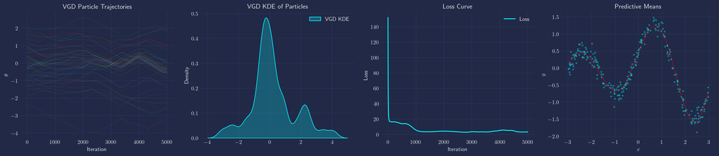

```python
key = jax.random.PRNGKey(42)
data, f_true = make_regression_data(n=256, key=key)
N, d = data["x"].shape

# Init Fourier mixture
Q0 = init_fourier_particles(n_particles=48, d=d, key=key, w_scale=1.0, phase_uniform=True)

# Predictor + Loss
prior = NormalDiag(sd=1.0)
predictor = FourierPredictor(prior_plus=prior, prior_minus=prior, data = data, x_key="x", y_key="y")
loss = ISFDeterministicRiskLoss(loss_and_grad=squared_loss_and_grad)

# Kernel & params (adjust KernelParams(...) if your signature differs)
kparams = KernelParams(lengthscale=jnp.asarray(1.), amplitude=jnp.asarray(1.0))
kernel = RBFKernel()

# Pre-train diagnostics
f0 = predictor.predict(Q0)

# Run VGD
out = isf(
    model=predictor,
    loss=loss,
    kernel=kernel,
    kparams=kparams,
    eps_theta=1e-2,
    eps_alpha = 1e-4,
    lambda_skl = 1.,
    Q0=Q0,
    steps=5000,
    ema_alpha=1.0,
    use_median_lengthscale=True,
    return_metrics=True,
)
Qhat, metrics = out if isinstance(out, tuple) else (out, None)

Qfinal, history = out
plot_1d_predictive_output(Qfinal, history, predictor)
plt.show()
```

## Classification

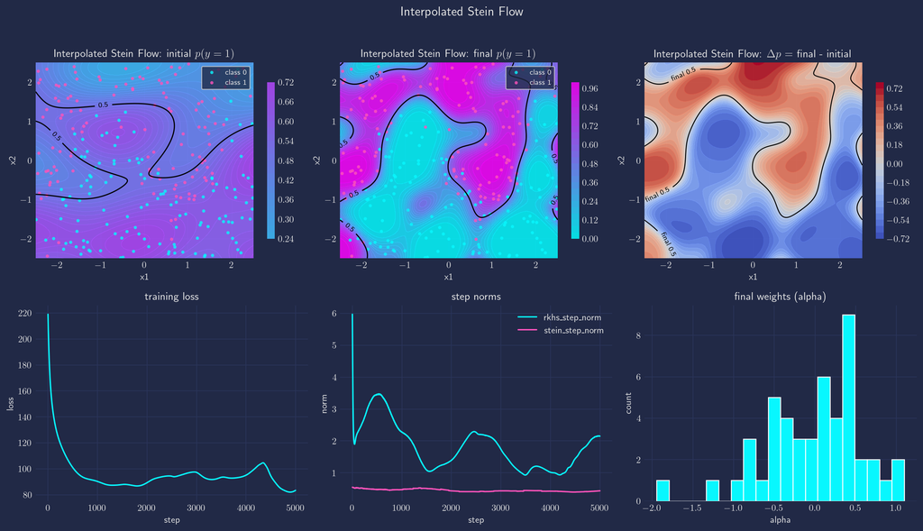

```python
data, logits = make_classification_data(n=256, key=key)
N, d = data["x"].shape

# Init Fourier mixture
Q0 = init_fourier_particles(n_particles=48, d=d, key=key, w_scale=1.0, phase_uniform=True)

# Predictor + Loss
prior = NormalDiag(sd=1.0)
predictor = FourierPredictor(prior_plus=prior, prior_minus=prior, data = data, x_key="x", y_key="y")
loss = ISFDeterministicRiskLoss(loss_and_grad=logistic_loss_and_grad)

# Kernel & params (adjust KernelParams(...) if your signature differs)
kparams = KernelParams(lengthscale=jnp.asarray(1.), amplitude=jnp.asarray(1.0))
kernel = RBFKernel()

# Pre-train diagnostics
f0 = predictor.predict(Q0)

# Run VGD
out = isf(
    model=predictor,
    loss=loss,
    kernel=kernel,
    kparams=kparams,
    eps_theta=1e-2,
    eps_alpha = 1e-4,
    lambda_skl = 1.,
    Q0=Q0,
    steps=5000,
    ema_alpha=1.0,
    use_median_lengthscale=True,
    return_metrics=True,
)
Qhat, metrics = out if isinstance(out, tuple) else (out, None)
Qfinal, history = out

plot_isf_results(
    predictor=predictor,
    data=data,
    Q0=Q0,
    Qhat=Qhat,
    metrics=metrics,
    grid_lim=2.5,
    grid_n=200,
    title_prefix="Interpolated Stein Flow"
)
plt.show()
```

# **Does it work?** (experimental results in $\mathbb{Q}_p$)

## $p$-adic numbers

For a prime $p$, the **$p$-adic absolute value** on $\mathbb{Q}$ is
$$|x|_p=\begin{cases}
p^{-k}\, & x=p^k\frac{a}{b},\; a,b\in\mathbb{Z}, \; p\nmid a,b, \\
0,& x=0.
\end{cases}$$
Numbers divisible by many powers of $p$ are **small** $p$-adically (e.g. $|8|_2=2^{-3}$).

Let $v_p(x)\in\mathbb{Z}\cup{\infty}$ be the **$p$-adic valuation** (largest $k$ with $p^k\mid x$ and $v_p(0)=\infty$). Then $|x|_p=p^{-v_p(x)}$ and
$$|x+y|_p \le \max\{|x|_p,|y|_p\}\quad\text{(ultrametric inequality).}$$

**Completions.** The completion of $\mathbb{Q}$ under $|\cdot|_p$ is $\mathbb{Q}_p$. Elements have expansions
$$x=\sum_{i=k_0}^{\infty} a_i p^i, \qquad a_i\in\{0,\dots,p-1\}, \; k_0\in\mathbb{Z},$$
i.e. **only finitely many negative powers** occur; for $\mathbb{Z}_p$ (the compact open unit ball) we have $k_0\ge 0$.

**Balls and measure.** Closed balls are cosets $a+p^m\mathbb{Z}_p$. With Haar measure $\mu$ normalised by $\mu(\mathbb{Z}_p)=1$, one has $\mu(a+p^m\mathbb{Z}_p)=p^{-m}$.

## Hierarchical data and $p$-adics

The ultrametric induces a **tree**: each ball $a+p^m\mathbb{Z}_p$ splits into $p$ disjoint children $a+bp^m+p^{m+1}\mathbb{Z}_p$, $b\in{0,\dots,p-1}$. Two points are close iff they agree to many **leading base-$p$ digits**:
$$v_p(x-y)=\text{length of the longest common prefix of the $p$-adic digit strings of $x,y$.}$$

**Canonical encodings.**

- **Binary/quad strings** (e.g. taxonomy, DNA): choose $p=2$ or $p=4$. Encode a finite string $s=(s_0,\dots,s_{L-1})$ as $x=\sum_{i=0}^{L-1} s_i p^i\in\mathbb{Z}_p$. Then
  $$v_p(x-x')=\min{i: s_i\neq s_i'}\quad(\text{or } \infty \text{ if identical}),$$
  so distance equals **first divergence depth** in the tree.
- **General rooted trees** of out-degree $\le p$: label edges $0,\dots,p-1$ from root and encode the path label as above.

This makes $\mathbb{Q}_p$ a natural host for **clustering**, **phylogenies**, and **any prefix-based similarity**.

## Fourier transform ($p$-adic Fourier analysis)

Consider the LCA group $(\mathbb{Q}_p,+)$ with Haar measure $\mu$ ($\mu(\mathbb{Z}_p)=1$). Fix the **standard additive character** $\psi:\mathbb{Q}_p\to\mathbb{T}$ that is trivial on $\mathbb{Z}_p$ and non-trivial on $p^{-1}\mathbb{Z}_p$ (concretely, $\psi(x)=e^{2\pi i {x}_p}$, where ${x}_p\in\mathbb{Q}/\mathbb{Z}$ is determined by the finitely many negative-power digits of $x$).

- **Fourier/Gelfand transform**:
  $$\widehat{f}(\xi)=\int_{\mathbb{Q}_p} f(x)\,\psi(\xi x)\,d\mu(x),\qquad \xi\in\mathbb{Q}_p.$$
- **Inversion/Plancherel** (with dual Haar $d\xi$):
  $$f(x)=\int_{\mathbb{Q}_p} \widehat{f}(\xi)\,\psi(-\xi x)\,d\xi\,\qquad |f|_2=|\widehat f|_2.$$
- **Characters.** Every continuous character is $\chi_\xi(x)=\psi(\xi x)$ for a unique $\xi\in\mathbb{Q}_p$; the dual group is $\widehat{\mathbb{Q}}_p\cong\mathbb{Q}_p$.

**Practical evaluation.** If computations are at resolution $m$ (finite strings/digits), then
$$\chi_\xi(x)=\exp\Big(2\pi i \;\frac{(\xi x)\bmod p^m}{p^m}\Big),$$
so you only need modular arithmetic on integers of size $p^m$.

## Regression

```
[1D] M=8, k=8, cos+sin spectrum-init ridge MSE: 1.308472
[1D] M=8, k=8, cos+sin spectrum-init ridge MSE: 0.008831
```

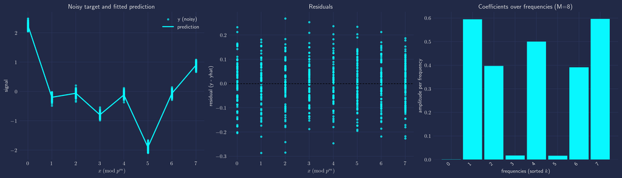

```python
p, m = 2, 3
X, y, truth = make_p_adic_regression_data_1d(p=p, m=m, N=600, key=jax.random.PRNGKey(42))
predictor = PAdicFourierPredictor(p=p, m=m, data={"x": X, "y": y}, use_sin=True)

M = predictor.modulus()
k = 8  # number of frequencies to keep
Xi0 = predictor.pick_freqs_via_sampled_dft(X, y, M, k)   # (k,1)
# cos+sin => alpha length is 2k; phases unused here (keep zeros)
phi0   = jnp.zeros((k,), dtype=jnp.float32)
alpha0 = jnp.zeros((2 * k,), dtype=jnp.float32)

Q = PAdicMixtureLike(Xi=Xi0, phi=phi0, alpha=alpha0)

y_pred = predictor.predict(Q)
mse_old = jnp.mean((y_pred - y) ** 2)
print(f"[1D] M={M}, k={k}, cos+sin spectrum-init ridge MSE: {float(mse_old):.6f}")

# Build design and ridge
Phi = predictor.features_pointwise(Q)          # (2k, N) since use_sin=True
alpha_hat = solve_alpha_ridge(Phi, y, lam=1e-3)
Q = Q.replace_alpha(alpha_hat)

y_pred = predictor.predict(Q)
mse = jnp.mean((y_pred - y) ** 2)
print(f"[1D] M={M}, k={k}, cos+sin spectrum-init ridge MSE: {float(mse):.6f}")

plot_1d_fit(X, y, Q, predictor)
```

## Regression

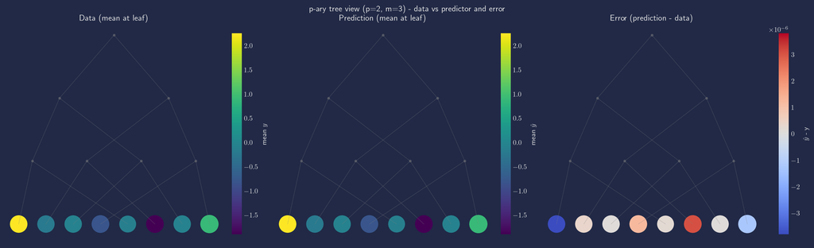

```python
plot_p_adic_tree_with_predictor(X, y, Q, predictor, p=predictor.p, m=predictor.m,)
```

# Stein enhanced MCMC dynamics

## Big picture

**Goal:** Generate high-quality (ideally independent) samples from a target density $\pi$.

**Standard Approaches:**

1. **MCMC** produces asymptotically exact samples but with *autocorrelation*; thinning/post-processing is usually required.
2. **SVGD** (Stein Variational Gradient Descent) gives *deterministic*, interacting particles with built-in **repulsion**, but needs a differentiable score $\nabla\log\pi$ and often struggles on **multimodal** targets.

**Idea:** For *any* $\pi$-invariant Markov kernel $P$ (or generator $\mathcal{A}$) we:

- take its **Stein operator** $T_\pi$,
- build the **Stein RKHS geometry** induced by a kernel $k$,
- construct an **analogue of SVGD**

This yields a **generalised SVGD** whose update is a “particle version” of the given MCMC—preserving invariance while adding SVGD style **repulsion**. With Metropolis–Hastings (MH), you get a **Stein-tilted MH** step that remains $\pi$-invariant but encourages diversity.

## Aside: Stein Operators

A **Stein operator** for a target $\pi$ is any operator $T_\pi$ such that

$$\mathbb{E}_{X\sim \pi}[ (T_\pi f)(X)] = 0.$$

There are *three kinds* of “Stein” operators which can make things confusing:

- **Generators on scalars:** An operator $\mathcal{A}_\pi$ which takes in **scalar-valued** functions and outputs **scalar-valued** functions.

  $$\mathcal{A}_\pi f = \nabla \cdot \nabla f + \nabla\log\pi \cdot \nabla f$$
- **Vector to scalar:** An operator $\mathcal{S}_\pi$ which takes in **vector-valued** functions and outputs **scalar-valued** functions.
  $$\mathcal{S}_\pi \phi = \nabla \cdot \phi + \nabla\log\pi \cdot \phi.$$
- **Scalar to vector (Stein feature operator):** An operator $\mathcal{G}_\pi$ which takes in **scalar-valued** functions and outputs **vector valued** functions.
  $$\mathcal{G}_\pi f = \nabla f + f \, \nabla \log \pi.$$

They are related:

$$\mathcal{A}_\pi f = \mathcal{S}_\pi (\nabla f) = \nabla \cdot (\mathcal{G}_\pi f).$$

### Creating Stein Operators

A **natural** way to construct a Stein operator is through Markov processes which leave the target $\pi$ invariant.

#### Discrete Time

For a **discrete time** $\pi$-invariant Markov process with Markov kernel $P$, we can define the **Markov-Stein** operator associated with $P$:

$$(T_\pi f)(x) \coloneqq (P f)(x)-f(x).$$

It satisfies the Stein identity $\mathbb E_\pi[T_\pi f]=0$ for bounded measurable $f$ since $\pi P = \pi$ and $\int P f\,\mathrm{d}\pi = \int f\,\mathrm{d}\pi$.

#### Continuous Time

In a continuous time $\pi$-invariant Markov process, we can **construct** a Stein operator via the **semigroup** or its **generator**:

1. **Semigroup:** Define $\mathcal{S}_t f := P_t f - f$, with $(P_t)_{t\geq 0}$ a $\pi$ invariant semigroup. Then
   $$\mathbb{E}_\pi[\mathcal{S}_t f] = \int (P_t f - f) \, d\pi = 0,$$
2. **Generator:** Define $\mathcal{S}_\pi := \mathcal{A}$ with $\mathcal{A}$ a $\pi$ invariant generator, then
   $$\mathbb{E}_\pi[\mathcal{S}_\pi f] = \mathbb{E}_\pi[\mathcal{A} f] = \mathbb{E}_\pi\left[\lim_{t\to 0^+} \frac{P_t f - f}{t}\right] = 0.$$

## Introduction to Vanilla SVGD

Let $\pi$ be a target density on $\mathbb{R}^d$ and $Q$ a current approximation. The KL divergence is:

$$\mathrm{KL}(Q \| \pi) = \int \log\left(\frac{dQ}{d\pi}\right) \,\mathrm{d}Q.$$

Consider the infinitesimal transport $T_\varepsilon(x)=x+\varepsilon\,\phi(x)$ with a vector field $\phi:\mathbb{R}^d\to\mathbb{R}^d$. We choose $\phi$ to maximise the **instantaneous decrease** of KL:

$$\min_{\phi}\ \left.\frac{d}{d\varepsilon} \mathrm{KL}\big((T_\varepsilon)_\# Q \| \pi\big)\right|_{\varepsilon=0}.$$

By a calculation involving change of variables and a Taylor series expansion of the density of $(T_\varepsilon)_\# Q$, it can be shown:

$$\frac{d}{d\varepsilon} \left.\mathrm{KL}( (T_\varepsilon)_\# Q \| \pi )\right|_{\varepsilon = 0} = -\mathbb{E}_{X\sim Q}\left[ (\mathcal{S}_\pi \phi)(X) \right],$$

where $\mathcal{S}_\pi \phi = \phi \cdot \nabla \log \pi + \nabla\cdot\phi$.

Now restrict $\phi$ to the **vector-valued RKHS**
$$\mathcal H_K = \bigoplus_{i=1}^d \mathcal H_k,
\qquad K(z,x)=k(z,x)\,I_d,$$
where $k:\mathbb{R}^d\times\mathbb{R}^d\to\mathbb{R}$ is a **scalar** positive-definite kernel and $I_d$ is the $d\times d$ identity. Using the reproducing properties in $\mathcal H_K$, the functional $\phi \mapsto \mathbb{E}_Q[\mathcal{S}_\pi \phi]$ has Riesz representer
$$\boxed{\;
\Phi_Q(z) = \mathbb{E}_{X\sim Q}\left[k(z,X)\nabla\log\pi(X) + \nabla_X k(z,X)\right].
\;}$$
where $\nabla_X k(z,X)$ denotes the gradient of $k$ w.r.t. its **second** argument.

Then, since $\mathcal{H}_K$ is a Hilbert space, Cauchy-Schwarz tells us:

$$-\frac{d}{d\varepsilon} \left.\mathrm{KL}( (T_\varepsilon)_\# Q \| \pi )\right|_{\varepsilon = 0} = \mathbb{E}_{X\sim Q}\left[ (\mathcal{S}_\pi \phi)(X) \right] = \langle \phi, \Phi_Q \rangle_{\mathcal{H}_K} \leq \|\phi\|_{\mathcal{H}_K} \|\Phi_Q\|_{\mathcal{H}_K}.$$

We wish to **maximise this**. Therefore, the **steepest descent direction** over the unit ball is $\phi^* = \tfrac{\Phi_Q}{\|\Phi_Q\|_{\mathcal{H}_K}}$. In practice we use the field
$$\boxed{\;\phi_{\text{SVGD}}(z) = \Phi_Q(z)
=\mathbb{E}_{X\sim Q}\left[k(z,X)\nabla\log\pi(X) + \nabla_X k(z,X)\right].}$$

A single Euler step updates particles $x_i\leftarrow x_i+\eta\,\phi_{\text{SVGD}}(x_i)$. Moreover,
$$\left.\frac{d}{d\varepsilon}\ \mathrm{KL}\big((T_\varepsilon)_\# Q \| \pi\big) \right|_{\varepsilon = 0}
= -\|\Phi_Q\|_{\mathcal H_K}^2,$$
i.e. the squared **kernel Stein discrepancy** (KSD) equals the instantaneous KL decrease along $\phi_{\text{SVGD}}$.

**Empirical form:** With particles $\{x_j\}_{j=1}^n$ defining an empirical measure $Q = \tfrac{1}{n}\sum_{j=1}^n \delta_{x_j}$, the SVGD update becomes:
$$\phi_{\text{SVGD}}(z) = \frac{1}{n}\sum_{j=1}^n \Big[k(z,x_j)\,\nabla\log\pi(x_j) + \nabla_{x_j} k(z,x_j)\Big].$$

## The (rough) Generalisation

In **vanilla SVGD**, the “Stein field” was
$$\phi_{\text{SVGD}}(z)
=\mathbb{E}_{X\sim Q}\left[k(z,X)\nabla\log\pi(X) + \nabla_X k(z,X)\right] = \mathbb{E}_{X\sim Q}[\mathcal{G}_\pi^X k(z,X)],$$
where $(\mathcal{G}_\pi f)(x) = f(x) \nabla\log\pi(x) + \nabla f(x)$ is the scalar $\to$ vector Stein feature operator.

For a **Markov-Stein** operator $\mathcal{S}_P f = Pf - f$, this implies we want something like:

$$\phi_{P\text{-SVGD}}(z) = \mathbb{E}_{X\sim Q}[\mathcal{S}_P^X k(z,X)].$$

### Issues

- As written, the $\phi_{P\text{-SVGD}}(z)$ is not a **transport map** - it is **scalar-valued**!
- Even if it did make sense, how can it be justified?
- The derivation of the standard SVGD assumed the use of **KL divergence** and transports of the form
  $$T_\varepsilon = \mathrm{Id} + \varepsilon\,\phi.$$
- With these assumptions, the **Langevin Stein operator** $\mathcal{S}_\pi$ appeared.

## Alternative View

Instead of considering a **transport map** to move $Q$, we consider a family of **Markov kernels**:

$$\{ P_{\varepsilon} \mid -\epsilon_0 \leq \varepsilon \leq \epsilon_0, \; P_0 = P \}.$$

Define

$$F(\varepsilon) = \mathrm{KL}(Q \, P_\varepsilon \| \pi ).$$

We seek the Markov kernel which **maximises the instaneous decrease of KL**:

$$F'(0) = \frac{d}{d\varepsilon} \left. \mathrm{KL}(Q \, P_\varepsilon \| \pi ) \right|_{\varepsilon = 0}.$$

### Constraints on $P_\varepsilon$

Let $(P_\varepsilon)_{\varepsilon}$ be a family of Markov kernels with $P_0=P$. For bounded measurable $f$, write
$$(P_\varepsilon f)(x)=\int f(y)\,P_\varepsilon(x,dy).$$
If the map $\varepsilon\mapsto P_\varepsilon f$ is differentiable at $0$ for all bounded $f$, define the **signed kernel derivative** $M$ by
$$(M f)(x)\;:=\;\left.\frac{d}{d\varepsilon}\,(P_\varepsilon f)(x)\right|_{\varepsilon=0}.$$
By Riesz–Markov, this means that for each fixed $x$, there exists a finite **signed** measure $M(x,\cdot)$ on the state space so that
$$(M f)(x)=\int f(y)\,M(x,dy).$$

**Intuitively**: $P_\varepsilon = P + \varepsilon M + o(\varepsilon)$ in the weak sense.

Now differentiate the standard identities:

**Stochasticity (row sums $=1$).**
For every $\varepsilon$ and $x$, $\int P_\varepsilon(x,dy)=1$. Differentiate at $0$:
$$\int M(x,dy)=0\quad\text{for all }x
\qquad\Longleftrightarrow\qquad
M\, 1 =0.$$

**$\pi$-invariance to first order.**
If $P_\varepsilon$ leaves $\pi$ invariant for all $\varepsilon$, then for every bounded $f$,
$$\int (P_\varepsilon f)(x)\,\mathrm{d}\pi(x)=\int f(x)\,\mathrm{d}\pi(x).$$
Differentiate at $0$:
$$\int (M f)(x)\,\mathrm{d}\pi(x)=0\quad\text{for all }f.$$
Equivalently, as a signed measure in $y$,
$$\int M(x,dy)\,\mathrm{d}\pi(x)=0
\qquad\Longleftrightarrow\qquad
\pi M=0.$$

**Reversibility (detailed balance) to first order.**
If each $P_\varepsilon$ is $\pi$-reversible, then for all measurable sets $A,B$:
$$\int_A\!\!\int_B \mathrm{d}\pi(x)\,P_\varepsilon(x,dy)
=
\int_A\!\!\int_B \pi(dy)\,P_\varepsilon(y,dx).$$
Differentiate at $0$ and use symmetry in $(A,B)$ to get, as measures on $\mathcal X\times\mathcal X$,
$$\pi(dx)\,M(x,dy)\;=\;\pi(dy)\,M(y,dx).$$
This is the “detailed balance at first order”.

### Parameterising $P_\varepsilon$

Assume $P$ is $\pi$-reversible and set
$$\mu(dx,dy):=\pi(dx)\,P(x,dy).$$
Then $\mu$ is symmetric: $\mu(dx,dy)=\mu(dy,dx)$.

A class of perturbations is obtained by weighting the jump $x\to y$ with a function $A(x,y)$ and compensating on the diagonal so rows still sum to zero:
$$(Mf)(x)=\int\big(f(y)-f(x)\big)\,A(x,y)\,P(x,dy).$$
Equivalently, as (signed) kernels,
$$M(x,dy)=A(x,y)\,P(x,dy)\;-\;\Big[\int A(x,z)\,P(x,dz)\Big]\,\delta_x(dy).
\tag{†}$$

Let’s check the three constraints and see what symmetry of $A$ is forced:

**Row sums.** With $f\equiv 1$, $(Mf)(x)=\int(1-1)\,A(\cdot)\,P=0$. So $M\mathbf 1=0$ holds for **any** $A$.

**$\pi$-invariance at first order.** For any $f$,
$$\int (Mf)(x)\,\mathrm{d}\pi(x)=\iint \big(f(y)-f(x)\big)\,A(x,y)\,\mu(dx,dy).$$
Swap $(x,y)$ and use symmetry of $\mu$ to see this integral is the negative of itself, hence $0$ **regardless of the symmetry of $A$**. Thus $\pi M=0$ always holds.

**Reversibility at first order.** Here the symmetry of $A$ matters. From (†),
$$\pi(dx)\,M(x,dy)=A(x,y)\,\mu(dx,dy)\;-\;\pi(dx)\,a(x)\,\delta_x(dy),
\qquad a(x):=\int A(x,z)\,P(x,dz).$$
Swapping $(x,y)$ we obtain $\pi(dy)\,M(y,dx)=A(y,x)\,\mu(dx,dy)-\pi(dy)\,a(y)\,\delta_y(dx)$. For these two signed measures to be equal, we must have on the **off-diagonal** (where $\delta$-terms vanish)
$$A(x,y)\,\mu(dx,dy)=A(y,x)\,\mu(dx,dy)
\quad\Rightarrow\quad
A(x,y)=A(y,x)\quad(\mu\text{-a.e.}).$$
The diagonal compensation terms then match automatically.

**Conclusion:** to *preserve reversibility to first order*, $A$ must be **symmetric** $\mu$-a.e.

## Derivation

### Step 1: Gâteaux derivative of $\mathrm{KL}$

Let $Q\ll \pi$ with density $\rho=\dfrac{dQ}{d\pi}$ and
$$\mathrm{KL}(Q\|\pi)=\int \rho\log\rho\,d\pi.$$
Consider a differentiable path of probability measures $(Q_\varepsilon)_{\varepsilon}$ with $Q_0=Q$ and
$$\dot Q := \left.\frac{d}{d\varepsilon} Q_\varepsilon \right|_{\varepsilon=0},
\qquad \dot Q(\mathcal X)=0.$$
Assume $Q_\varepsilon\ll\pi$ for $|\varepsilon|$ small with densities $\rho_\varepsilon=\dfrac{dQ_\varepsilon}{d\pi}$ differentiable at $\varepsilon=0$ $\pi$-a.e., and $\dot\rho:=\left.\dfrac{d}{d\varepsilon}\rho_\varepsilon \right|_{\varepsilon=0}$. Then $d\dot q=\dot\rho\,d\pi$.

Write $\varphi(t)=t\log t$. Then $\varphi'(t)=1+\log t$ and
$$F(\varepsilon):=\mathrm{KL}(Q_\varepsilon\|\pi)=\int \varphi(\rho_\varepsilon)\,d\pi.$$
By differentiation under the integral sign:
$$F'(0)=\int \varphi'(\rho)\,\dot\rho\,d\pi
=\int \bigl(1+\log\rho\bigr)\,d\dot Q.$$
Because $\dot Q(\mathcal X)=\int 1\,d\dot Q=0$, the constant “$1$” drops out:
$$F'(0)=\int \log\rho\,d\dot Q
=\int \log\!\Big(\frac{dQ}{d\pi}\Big)\,d\dot Q.$$

### Step 2: What is the allowable $\dot q$?

Given a current law $Q$, the one–step pushforward along $P_\varepsilon$ is $Q_\varepsilon:=Q\,P_\varepsilon$. Its tangent is
$$\dot Q
:=\left.\frac{d}{d\varepsilon}\, Q\,P_\varepsilon\right|_{\varepsilon=0}
= QM,
\qquad\text{i.e.}\quad
\langle f,\dot Q\rangle
=\int (Mf)(x)\,Q(dx).$$

Using the property of $M$:
$$\boxed{\;
\langle f,\dot q\rangle
=\iint \big(f(y)-f(x)\big)\,A(x,y)\,\underbrace{q(dx)\,P(x,dy)}_{=:~\mu_Q(dx,dy)}\;.
}
\tag{Tangent}$$
Here $\mu_q$ is the one–step coupling of $(Q,P)$. Note $\mu_q$ is generally **not symmetric** unless $Q=\pi$.

### Step 3: First variation of $\mathrm{KL}$

The Gâteaux derivative of KL gives
$$\frac{d}{d\varepsilon}\left.\mathrm{KL}(Q\,P_\varepsilon\|\pi) \right|_{\varepsilon=0}
=\int \log\!\Big(\frac{dQ}{d\pi}\Big)\,d\dot Q
=\left\langle \log\dfrac{dQ}{d\pi},\dot Q\right\rangle.$$
Therefore:
$$\boxed{\;
\frac{d}{d\varepsilon}\Big|_{\varepsilon=0}\mathrm{KL}(Q\,P_\varepsilon\|\pi)
= \iint \big(\log\dfrac{dQ}{d\pi}(y)-\log\dfrac{dQ}{d\pi}(x)\big)\,A(x,y)\,\mu_Q(dx,dy)\;.
}$$

This is the **general first–order formula** for any admissible perturbation (i.e. any symmetric $A$ in $(\dagger)$).